# Statistical Relationship and Analysis

## 2.9 Simulating Random Numbers from a linear model in r

Suppose we want to simulate data from the linear model:

$$y = \beta_0+\beta_1 x+ \epsilon$$

where epsilon has a normal distribution with sd =2, the intercept $\beta_0$ = 0.5 and the slope $\beta_1$ = 2

```r
set.seed(20)
x<- rnorm(100)
e<- rnorm(100,0,2)
y= 0.5 +2*x+e
summary(y)
```

```
   Min. 1st Qu.  Median    Mean 3rd Qu.    Max.
-6.4084 -1.5402  0.6789  0.6893  2.9303  6.5052
```

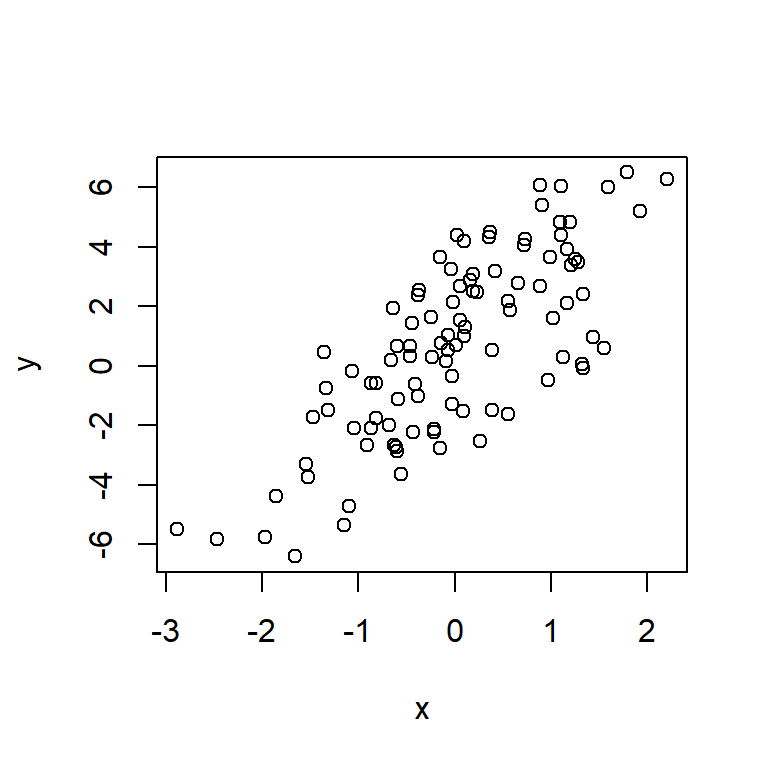

```r
plot(x,y)
```

if $x$ is binomial:

```r
set.seed(10)
set.seed(20)
x<- rbinom(100,1,0.5)
e<- rnorm(100,0,2)
y= 0.5 +2*x+e
summary(y)
```

```
   Min. 1st Qu.  Median    Mean 3rd Qu.    Max.
-3.4361 -0.2675  1.7804  1.5723  2.8810  6.9169
```

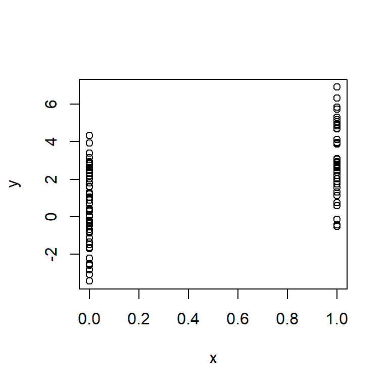

```r
plot(x,y)
```

Linear regression models the relationship between a dependent variable and one or more independent variables. Remember a well-fitting model doesn’t always imply causality.

# 3 Extending the linear models

## 3.1 Categorical predictors in regression models.

Sometimes we may want to include in the model a variable that is not numeric, for example gender. To do that we create what we call a dummy variable, for example $x_i = 1$ if the person is female and $x_i = 0$ if it is a male. The resulting model will be:
$$y_i=\beta_o+\beta_1x_i+\epsilon_i$$
which will result in this if the person is female:
$$y_i=\beta_o+\beta_1+\epsilon_i$$
and if the person is male:
$$y_i=\beta_o+\epsilon_i$$
so what this is telling us is that $\beta_1$ is the effect of being female vs the baseline (in this case male)

If we have more than two levels what we do is create more dummy variables. For example we look at three different etnicities, Asian, Caucasian and African American, we create:

$x_{i1} = 0$ if person is Asian and $x_{i1} = 1$ if the person is not Asian $x_{i2} = 0$ if person is Caucasian and $x_{i2} = 1$ if the person is not. We don’t need a level for African American because that will be deducted when $x_{i1} = 0$ and $x_{i2} = 0$. So for categorical variables we create $k-1$ dummy variables. The level with no dummy variable is known as *baseline*. The choice of a baseline will not affect the fit of the model, the residual sum of squares would be the same, but the coefficient and the $p$-values will change because each other category will be compared with the baseline.

The equation will now look like this:
$$y_1 = \beta_o+\beta_1x_{i1}+\beta_2x_{i2}+\epsilon_i
\begin{cases}
\beta_0 + \beta_1 + e_1 & \text{if condition 1} \\
\beta_0 + \beta_2 + e_1 & \text{if condition 2} \\
\beta_0 + e_1 & \text{if condition 3}
\end{cases}$$

Example

*The Carseats data from the library ISLR2 includes qualitative predictors such as shelveloc, an indicator of the quality of the shelving location—that is, the space within a store in which the car seat is displayed—at each location. The predictor shelveloc takes on three possible values: Bad, Medium, and Good. Given a qualitative variable such as shelveloc, R generates dummy variables automatically.*

```r
lm.fit <- lm(Sales ~ ShelveLoc,
    data = Carseats)
summary(lm.fit)
```

```
Call:
lm(formula = Sales ~ ShelveLoc, data = Carseats)

Residuals:
    Min      1Q  Median      3Q     Max
-7.3066 -1.6282 -0.0416  1.5666  6.1471

Coefficients:
                Estimate Std. Error t value             Pr(>|t|)
(Intercept)       5.5229     0.2388  23.131 < 0.0000000000000002 ***
ShelveLocGood     4.6911     0.3484  13.464 < 0.0000000000000002 ***
ShelveLocMedium   1.7837     0.2864   6.229         0.0000000012 ***
---
Signif. codes:  0 '***' 0.001 '**' 0.01 '*' 0.05 '.' 0.1 ' ' 1

Residual standard error: 2.339 on 397 degrees of freedom
Multiple R-squared:  0.3172,    Adjusted R-squared:  0.3138
F-statistic: 92.23 on 2 and 397 DF,  p-value: < 0.00000000000000022
```

```r
contrasts(Carseats$ShelveLoc)
```

```
       Good Medium
Bad       0      0
Good      1      0
Medium    0      1
```

The contrasts() function returns the coding that R uses for the dummy variables.

R has created a ShelveLocGood dummy variable that takes on a value of 1 if the shelving location is good, and 0 otherwise. It has also created a ShelveLocMedium dummy variable that equals 1 if the shelving location is medium, and 0 otherwise. A bad shelving location corresponds to a zero for each of the two dummy variables. The fact that the coefficient for ShelveLocGood in the regression output is positive indicates that a good shelving location is associated with high sales (relative to a bad location). And ShelveLocMedium has a smaller positive coefficient, indicating that a medium shelving location is associated with higher sales than a bad shelving location but lower sales than a good shelving location.

## 3.2 Interactions

In our previous examples, we have assume independence from one parameter to the others, but that is not always the case, sometimes the change in one predictor affects the results in another.

Example Imagine we run a campaign to sell a product, and we advertise in three mediums, newspapers, radio and tv. It could be that the effect of radio increases the effectiveness of the adds in tv, this in marketing is called synergy effect, and in statistics we refer to it as interaction effect. If we detect this interaction, spending part of our budget in radio and part on tv could be more effective than spending all in only the media with the most effect.

```r
Advertising <- readr::read_csv("data/Advertising.csv")
lm.fit<- lm(sales ~ TV + radio, data = Advertising)
summary(lm.fit)
```

```
Call:
lm(formula = sales ~ TV + radio, data = Advertising)

Residuals:
    Min      1Q  Median      3Q     Max
-8.7977 -0.8752  0.2422  1.1708  2.8328

Coefficients:
            Estimate Std. Error t value            Pr(>|t|)
(Intercept)  2.92110    0.29449   9.919 <0.0000000000000002 ***
TV           0.04575    0.00139  32.909 <0.0000000000000002 ***
radio        0.18799    0.00804  23.382 <0.0000000000000002 ***
---
Signif. codes:  0 '***' 0.001 '**' 0.01 '*' 0.05 '.' 0.1 ' ' 1

Residual standard error: 1.681 on 197 degrees of freedom
Multiple R-squared:  0.8972,    Adjusted R-squared:  0.8962
F-statistic: 859.6 on 2 and 197 DF,  p-value: < 0.00000000000000022
```

to include interactions in our model we create a new variable with the product of the two predictors. If we ignore newspaper our equation would be:

$$sales = \beta_0+\beta_1\times TV+\beta_2\times Radio + \beta_3 \times(radio\times TV)+ \epsilon$$

$$sales = \beta_0+(\beta_1 + \beta_3\times Radio) \times TV+\beta_2\times Radio + \epsilon$$
and if we get a summary of the linear model we will see if the interaction between tv and radio is indeed significant or not:

```r
lm.fit_interaction <- lm(sales ~ TV * radio , data = Advertising)
summary(lm.fit_interaction)
```

```
Call:
lm(formula = sales ~ TV * radio, data = Advertising)

Residuals:
    Min      1Q  Median      3Q     Max
-6.3366 -0.4028  0.1831  0.5948  1.5246

Coefficients:
              Estimate Std. Error t value            Pr(>|t|)
(Intercept) 6.75022020 0.24787137  27.233 <0.0000000000000002 ***
TV          0.01910107 0.00150415  12.699 <0.0000000000000002 ***
radio       0.02886034 0.00890527   3.241              0.0014 **
TV:radio    0.00108649 0.00005242  20.727 <0.0000000000000002 ***
---
Signif. codes:  0 '***' 0.001 '**' 0.01 '*' 0.05 '.' 0.1 ' ' 1

Residual standard error: 0.9435 on 196 degrees of freedom
Multiple R-squared:  0.9678,    Adjusted R-squared:  0.9673
F-statistic:  1963 on 3 and 196 DF,  p-value: < 0.00000000000000022
```

```r
# or
lm.fit_interaction <- lm(sales ~ TV + radio + TV:radio , data = Advertising)
summary(lm.fit_interaction)
```

```
Call:
lm(formula = sales ~ TV + radio + TV:radio, data = Advertising)

Residuals:
    Min      1Q  Median      3Q     Max
-6.3366 -0.4028  0.1831  0.5948  1.5246

Coefficients:
              Estimate Std. Error t value            Pr(>|t|)
(Intercept) 6.75022020 0.24787137  27.233 <0.0000000000000002 ***
TV          0.01910107 0.00150415  12.699 <0.0000000000000002 ***
radio       0.02886034 0.00890527   3.241              0.0014 **
TV:radio    0.00108649 0.00005242  20.727 <0.0000000000000002 ***
---
Signif. codes:  0 '***' 0.001 '**' 0.01 '*' 0.05 '.' 0.1 ' ' 1

Residual standard error: 0.9435 on 196 degrees of freedom
Multiple R-squared:  0.9678,    Adjusted R-squared:  0.9673
F-statistic:  1963 on 3 and 196 DF,  p-value: < 0.00000000000000022
```

the $p$-value of the interaction indicates that in our example this interaction is significant, we can also see how our R-squared is higher now (0.9678) than when we did not include the interaction in our model (0.8972). This means that (96.8-89.7)/(100-89.7)=69% of the variability in sales that remains after fitting the initial model has been explained by the interaction term.

The coefficients estimates in the table suggest that an increase in radio advertising of $1000 is associated with increased sales of $(\hat{\beta_2}+\hat{\beta_3}\times TV)\times 1000 = 29+1.1\times TV units$ An increase in TV advertising of $1000 is associated with an increase of sales of $(\hat{\beta_1}+\hat{\beta_3}\times radio)\times 1000 = 19+1.1\times radio units$

Sometimes it is the case that an interaction term has a very small $p$-value, but the associated main effects do not. The *hierarchy principle* states that if we include an interaction in a model, we should also include the main effects, even if the $p$-values associated with their coefficients are not significant.

## 3.3 Non-linear transformations of the predictors.

If a linear model does not quite fit our data:

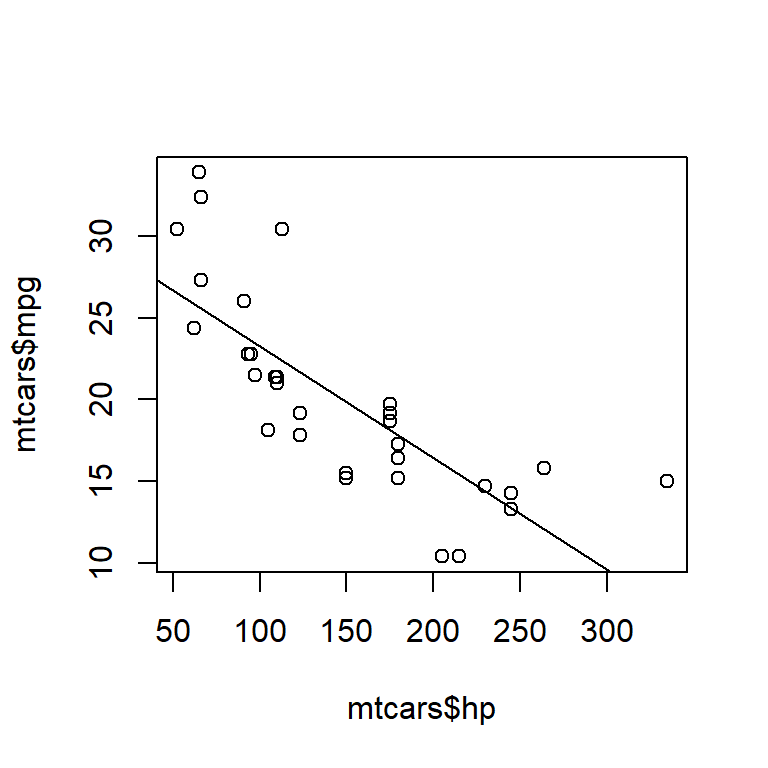

```r
lm.fit<- lm(mpg~ hp, data= mtcars)
plot(mtcars$hp, mtcars$mpg)
abline(lm.fit)
```

```r
summary(lm.fit)
```

```
Call:
lm(formula = mpg ~ hp, data = mtcars)

Residuals:
    Min      1Q  Median      3Q     Max
-5.7121 -2.1122 -0.8854  1.5819  8.2360

Coefficients:
            Estimate Std. Error t value             Pr(>|t|)
(Intercept) 30.09886    1.63392  18.421 < 0.0000000000000002 ***
hp          -0.06823    0.01012  -6.742          0.000000179 ***
---
Signif. codes:  0 '***' 0.001 '**' 0.01 '*' 0.05 '.' 0.1 ' ' 1

Residual standard error: 3.863 on 30 degrees of freedom
Multiple R-squared:  0.6024,    Adjusted R-squared:  0.5892
F-statistic: 45.46 on 1 and 30 DF,  p-value: 0.0000001788
```

we can transform this into a polynomial regression by making extra variables to accommodate polynomials, for example we add another variable horsepower squared:

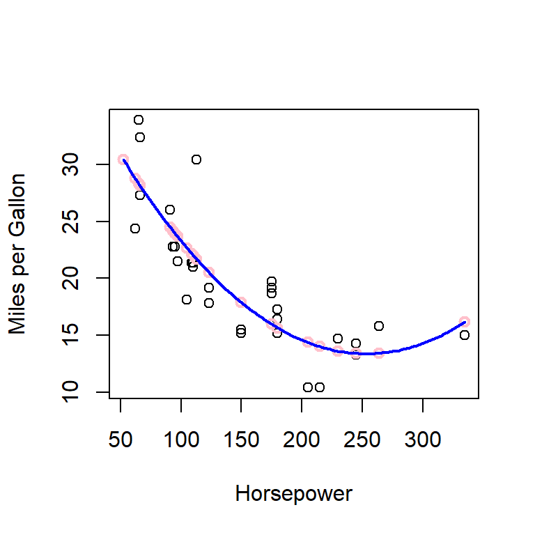

```r
lm.fit <- lm(mpg ~ hp + I(hp^2), data = mtcars)

plot(mtcars$hp, mtcars$mpg, xlab = "Horsepower", ylab = "Miles per Gallon")

points(mtcars$hp, fitted(lm.fit), col = "pink", lwd = 2)

#or if we want to show a line:
# Create a sequence of hp values for prediction
hp_seq <- seq(min(mtcars$hp), max(mtcars$hp), length.out = 100)

# Predict mpg for each hp value in the sequence
predicted_mpg <- predict(lm.fit, newdata = data.frame(hp = hp_seq))

lines(hp_seq, predicted_mpg, col = "blue", lwd = 2)
```

```r
summary(lm.fit)
```

```
Call:
lm(formula = mpg ~ hp + I(hp^2), data = mtcars)

Residuals:
    Min      1Q  Median      3Q     Max
-4.5512 -1.6027 -0.6977  1.5509  8.7213

Coefficients:
               Estimate  Std. Error t value            Pr(>|t|)
(Intercept) 40.40911720  2.74075944  14.744 0.00000000000000523 ***
hp          -0.21330826  0.03488387  -6.115 0.00000116297223609 ***
I(hp^2)      0.00042082  0.00009844   4.275            0.000189 ***
---
Signif. codes:  0 '***' 0.001 '**' 0.01 '*' 0.05 '.' 0.1 ' ' 1

Residual standard error: 3.077 on 29 degrees of freedom
Multiple R-squared:  0.7561,    Adjusted R-squared:  0.7393
F-statistic: 44.95 on 2 and 29 DF,  p-value: 0.000000001301
```

but there is a better way of fitting polynomials with r using the `poly()` function:

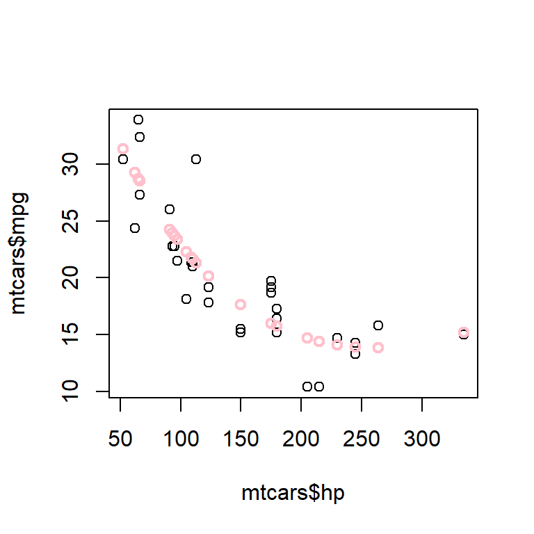

```r
lm.fit <- lm(mpg ~ poly(hp,4), data = mtcars)
plot(mtcars$mpg ~ mtcars$hp)
points(mtcars$hp, fitted(lm.fit), col = "pink", lwd = 2)
```

## 3.4 Potential problems in linear models

We already talked about most of them, but let’s do a summary:

1. **Non linearity**: The linear regression model assumes that there is a straight-line relationship between the predictors and the response. If the true relationship is far from linear, then virtually all of the conclusions that we draw from the fit are suspect. We saw how we can make use of the residual plot to see if the relation is liner or not when we talked about residuals
2. **Correlation of error terms**: An important assumption of the linear regression model is that the error terms are uncorrelated.If in fact there is correlation among the error terms, then the estimated standard errors will tend to underestimate the true standard errors and this will affect the $p$-values, confidence intervals etc. Why might correlations among the error terms occur? Such correlations frequently occur in the context of time series data, which consists of observations for which measurements are obtained at discrete points in time. time series. In many cases, observations that are obtained at adjacent time points will have positively correlated errors. In order to determine if this is the case for a given data set, we can plot the residuals from our model as a function of time. If the errors are uncorrelated, then there should be no discernible pattern. On the other hand, if the error terms are positively correlated, then we may see tracking in the residuals.Correlation among the error terms can also occur outside of time series data. For instance, consider a study in which individuals’ heights are predicted from their weights. The assumption of uncorrelated errors could be violated if some of the individuals in the study are members of the same family, eat the same diet,or have been exposed to the same environmental factors. In general, the assumption of uncorrelated errors is extremely important for linear regression as well as for other statistical methods, and good experimental design is crucial in order to mitigate the risk of such correlations.
3. **Non-constant variance of error terms (heteroscedasticity)** : error terms have a constant variance, Var(ϵi) = σ2. The standard errors, confidence intervals, and hypothesis tests associated with the linear model rely upon this assumption. Unfortunately, it is often the case that the variances of the error terms are non-constant. For instance, the variances of the error terms may increase with the value of the response
4. **Outliers**: An outlier is a point for which $y$ is far from the value predicted by the model. It is typical for an outlier that does not have an unusual predictor value to have little effect on the least squares fit. However, even if an outlier does not have much effect on the least squares fit, it can cause other problems. For instance it affects the RSE. Since the RSE is used to compute all confidence intervals and $p$-values, such a dramatic increase caused by a single data point can have implications for the interpretation of the fit. Residual plots can be used to identify outliers.
5. **High-leverage points**: Observations with high leverage have an unusual value for $x_i$. Removing a high leverage point has much more impact than removing an outlier. In a simple linear regression, high leverage observations are fairly easy to identify, since we can simply look for observations for which the predictor value is outside of the normal range of the observations. But in a multiple linear regression with many predictors, it is possible to have an observation that is well within the range of each individual predictor’s values, but that is unusual in terms of the full set of predictors.
6. **Collinearity**: we already dedicated a section to these problem.

# 4 Introduction to ANOVA (Analysis of Variance)

Analysis of variance, or ANOVA, is used to test **the relationship between a categorical and a quantitative variable**. Specifically, it test the null hypothesis that the population mean of the quantitative variable is the same in each of the groups. A low $p$-value indicates that the data would be unlikely if in fact those population means where equal.

ANOVA requires that the data be relatively symmetric in each group and not include extreme outliers. Additionally, the spread of the data within the groups should be similar. Always plot your data before running ANOVA to check these assumptions.

ANOVA is an omnibus test: on it’s own, it does not say anything about which group or groups might be interesting.

We are going back to our attrition dataset and analyse if the variable of work life balance gives us any information about the money they make (MonthlyRate). A first intuitive approach is to calculate the average MontlyRate per group:

```r
file <- here::here("data", "attrition1.xlsx")
attrition1 <- read_excel(file)
attrition1 %>% group_by(WorkLifeBalance) %>%
  summarise (mean(MonthlyRate))
```

```
# A tibble: 4 × 2
  WorkLifeBalance `mean(MonthlyRate)`
  <chr>                         <dbl>
1 Bad                          13901.
2 Best                         13802.
3 Better                       14515.
4 Good                         14267.
```

this shows that there is in fact a difference but, is this difference important or significant?

One first approach to answer this question is observing the data in a boxplot:

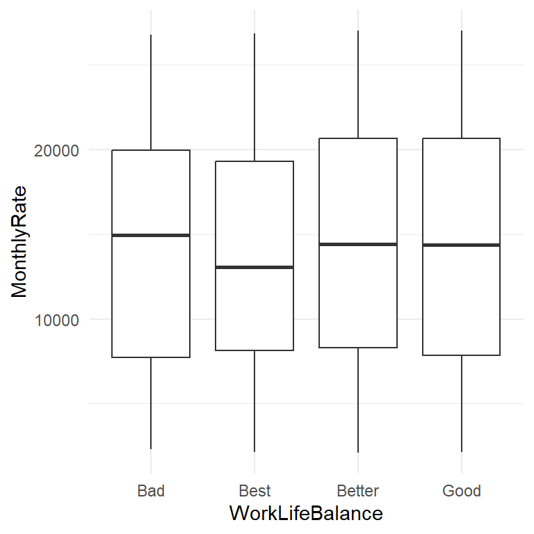

This already shows us that the spread of the data in each of the groups is big compared to the the spread of the data between the groups, but one way we can test this is doing an ANOVA test that is going to compare the variances within the groups to the variance between the groups.

```r
testResult<- (aov(MonthlyRate ~ WorkLifeBalance, data = attrition1))
sumRes<- summary(testResult)
sumRes
```

```
                  Df      Sum Sq  Mean Sq F value Pr(>F)
WorkLifeBalance    3    83646464 27882155   0.552  0.647
Residuals       1403 70876092211 50517528
```

Our null hypothesis is that all group means are equal. If we had only two groups, we would use a t test

$$t=\frac{difference\ in \ sample\ means}{SE\ of\ difference}$$

now we generalize this idea to the instance when we have several groups. If the differences between the samples means are large relative to the variability within the groups, this suggest that our null hypothesis is not true. In contrast, if the differences in the means are quite small compared with the variability within each groups, that suggest that the differences in the means are due to variability in the sample.

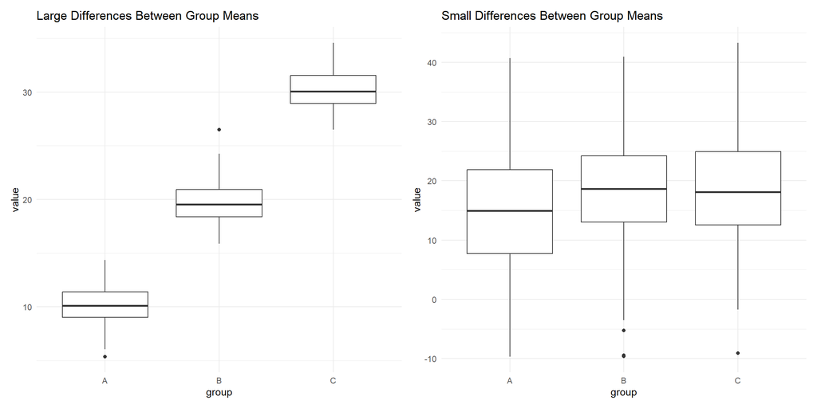

```r
#|echo: FALSE
# Set seed for reproducibility
set.seed(123)

# Generate data for large differences between group means
group_A1 <- rnorm(100, mean = 10, sd = 2)
group_B1 <- rnorm(100, mean = 20, sd = 2)
group_C1 <- rnorm(100, mean = 30, sd = 2)

# Generate data for small differences between group means
group_A2 <- rnorm(100, mean = 15, sd = 10)
group_B2 <- rnorm(100, mean = 17, sd = 10)
group_C2 <- rnorm(100, mean = 19, sd = 10)

# Create data frames
data_large_diff <- data.frame(value = c(group_A1, group_B1, group_C1),
                              group = rep(c("A", "B", "C"), each = 100))

data_small_diff <- data.frame(value = c(group_A2, group_B2, group_C2),
                              group = rep(c("A", "B", "C"), each = 100))

# Create boxplots
p1 <- ggplot(data_large_diff, aes(x = group, y = value)) +
  geom_boxplot() +
  ggtitle("Large Differences Between Group Means") +
  theme_minimal()

p2 <- ggplot(data_small_diff, aes(x = group, y = value)) +
  geom_boxplot() +
  ggtitle("Small Differences Between Group Means") +
  theme_minimal()

# Combine plots side by side
combined_plot <- p1 + p2

# Print the combined plot
print(combined_plot)
```

But unfortunately things are not as easy as looking at the boxplots, the reason is that according to the square root law, the chance variability in the sample mean is smaller than the chance variability in the data, so the evidence against $H_0$ is not obvious from the boxplots. Computation is necessary.

We have k groups with n observations:

| observation | group 1 | group 2 | group k |
| --- | --- | --- | --- |
| 1 | $y_{11}$ | $y_{12}$ | $y_{1k}$ |
| 2 | $y_{21}$ | $y_{22}$ | $y_{2k}$ |
| … | … | … | … |
| n | $y_{n1}$ | $y_{n2}$ | $y_{nk}$ |

in total there are $N=n_1+n_2+\cdots+n_k$ observations. The sample mean of one group is $\bar{y_j}=\frac{1}{n_j}\sum_{i=1}^{n_j}y_{ij}$ and the overall sample mean or grand mean is $\bar{\bar{y}}= \frac{1}{N}\sum_{j=1}^{k}\sum_{i=1}^{n_j}y_{ij}$

The analysis of variance compute two important variables, one is the **treatment sum of squares (SST)** that look at the difference between the group means to the overall mean

$$SST=\sum_j\sum_i(\bar{y_j}-\bar{\bar{y}})^2
\tag{6}$$

and has k-1 degrees of freedom.

If we divide this by its degrees of freedom we get what is called the **treatment mean square (MST)** and measures the variability of the treatment means $\bar{y_j}$

$$MST= \frac{SST}{k-1}
\tag{7}$$

The other quantity we are interested in is the **error sum of squares (SSE)** where we look at the difference between each observation and the group mean.

$$SSE= \sum_j\sum_i({y_{ij}}-\bar{y_j})^2
\tag{8}$$

and has N-k degrees of freedom.

Dividing the error sum of square by its degrees of freedom we get what is called the **error mean square or Mean Square for Error (MSE)** and measures the variability within the groups. Not to be confused with the the MSE (Mean Squared Error) that we saw in linear model. In both cases, MSE is a measure of variability of the errors, but In ANOVA, MSE (Mean Square for Error) assesses within-group variance. In linear models, MSE (Mean Squared Error) assesses the goodness of fit of the model by looking at prediction errors.

$$MSE= \frac{SSE}{N-k}
\tag{9}$$

Since we want to compare the variation between the groups to the variation within the groups we look at the ratio

$$F= \frac{MST}{MSE}
\tag{10}$$

Under the null hypothesis of equal group means this ratio should be about 1. It will not be exactly one due to sampling variability. It follows a F-distribution with k-1 and N-k degrees of freedom. Large values of F suggest that the variation between groups is unusually large. We reject the null hypothesis if F is the right 5% of the tail, i.e. when the $p$-value is smaller than 5%.

The result of the test is summarized in the ANOVA table:

| Source | df | Sum of Squares | Mean Square | F | p-value |
| --- | --- | --- | --- | --- | --- |
| Treatment | k-1 | SST | MST | MST/MSE |  |
| Error | N-k | SSE | MSE |  |  |
| Total | N-1 | TSS |  |  |  |

Where **TSS is the Total Sum of Squares** and measures the total variability in the data (the overall variation of the observed data points around their mean):

$$TSS=\sum_j\sum_i({y_j}-\bar{\bar{y}})^2
\tag{11}$$

### 4.0.1 The one-way ANOVA model

The idea behind the anova table is that each observation is generated as the sum of a treatment $\mu_j$ plus and error term $\epsilon_{ij}$ (measurment of error) that follow the normal curve with mean 0 and common variance $\sigma^ 2$

$$y_{ij}=\mu_j+\epsilon_{ij}$$

our null hypothesis is that all treatment means are the same $\mu_1=\mu_2=\cdots=\mu_k$ Instead of looking at the group means it is helpful to look at deviations from an overall mean $\mu$ that deviation is represented by the greek letter ‘tau’ and called the **treatment effect** $\tau_j=\mu_j-\mu$ so the model is the overall mean plus the deviation plus an error term
$$y_{ij}=\mu+\tau_j+\epsilon_{ij}$$

We estimate the overall mean $\mu$ by the grand mean $\bar{\bar{y}}$. then the estimate $\tau_j=\bar{y_j}-\bar{\bar{y}}$ and the estimate of the error is the residual $\epsilon_{ij}=y_{ij}-\bar{y_j}$. so we can write the previous equation like this:
$$y_{ij}=\mu+\tau_j+\epsilon_{ij}=\bar{\bar{y}}+(\bar{y_j}-\bar{\bar{y}})+(y_{ij}-\bar{y_j})$$

now if we move $\bar{\bar{y}}$ to the left of the equation:

$$y_{ij}-\bar{\bar{y}}=(\bar{y_j}-\bar{\bar{y}})+(y_{ij}-\bar{y_j})$$

and we sum and square the terms:

$$\sum_{j} \sum_{i} (y_{ij} - \bar{y}_{i})^2 = \sum_{j} \sum_{i} (y_{ij} - \bar{y}_{j})^2 + \sum_{j} \sum_{i} (\bar{y}_{j} - \bar{y}_{i})^2$$

which is equal to say:

$$TSS=SST+SSE
\tag{12}$$
Which means that total variation can be split into two sources, the treatment sum of squares and the error sum of squares. This is the decomposition that is behind the ANOVA table.

ANOVA Assumptions

- Data are normally distributed
- The F-test assumes that all the groups have the same variance. This can be roughly checked with side by side plots, but there are formal test we can perform as well.
- The data are independent within and across groups. This would be the case if the subjects were assigned treatment at random. On the other hand, if the data was acquired from an observational study, we need to be very careful because this assumption would not be met and there could be cofounders so we will not be able to claim that there is causation with the treatment and the results of the tests.

## 4.1 Advanced ANOVA Techniques

Now we are going to use the mpg_2008 data set again to see if there is a difference in highway millage with respect to the ‘Drive’ categorical variable (front wheel, rear wheel and 4 wheel drive). Let’s do the same we did above and calculate the average per group first

```r
mpg_2008 |>
  group_by(drv) |>
  dplyr::summarize(mean(hwy))
```

```
# A tibble: 3 × 2
  drv   `mean(hwy)`
  <chr>       <dbl>
1 4            19.5
2 f            28.4
3 r            21.3
```

and we plot the data:

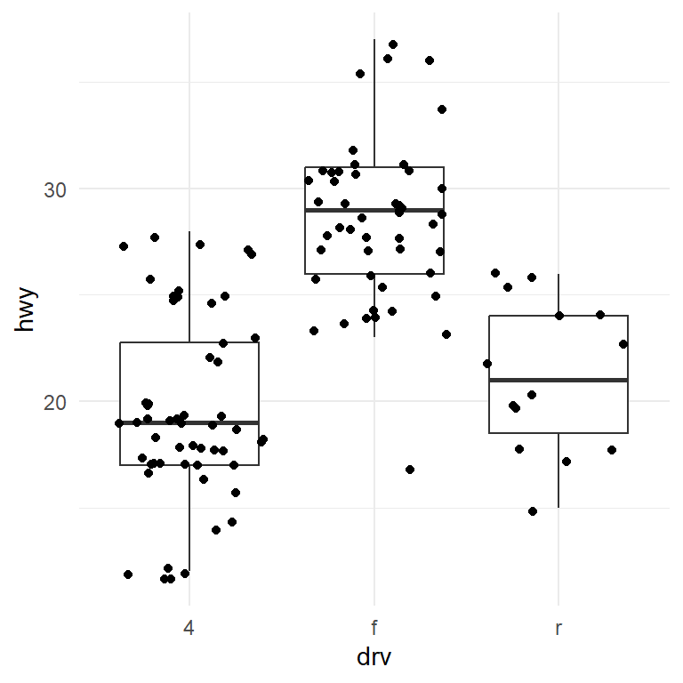

The boxplot allows us to see that the spread of the data in these groups is similar (the width of these boxes is about the same) so we can run an anova test on these data.

if we calculate the anova for this we find that the evidence support the hypothesis that there is in fact a difference in hwy between these groups:

```r
model <- aov(hwy ~ drv, data = mpg_2008)
summary(model)
```

```
             Df Sum Sq Mean Sq F value              Pr(>F)
drv           2   2140    1070    66.8 <0.0000000000000002 ***
Residuals   114   1826      16
---
Signif. codes:  0 '***' 0.001 '**' 0.01 '*' 0.05 '.' 0.1 ' ' 1
```

As we mentioned, the ANOVA test does not tell us anything about each group in particular, for this we can run another test, one recommended is the **Tukey Honest Significant Difference** test and this will give us a $p$-value and a confidence interval for each pair of categories in our data.

```r
TukeyHSD(model)
```

```
  Tukey multiple comparisons of means
    95% family-wise confidence level

Fit: aov(formula = hwy ~ drv, data = mpg_2008)

$drv
         diff        lwr       upr     p adj
f-4  8.967498   7.092124 10.842873 0.0000000
r-4  1.804233  -1.046509  4.654975 0.2933625
r-f -7.163265 -10.043796 -4.282734 0.0000001
```

The Tukey Honest Significant Difference test is better than running a Welch Two sample test by selecting just two variables in our dataset and testing one against the other. If we just run three different t-test comparing the three groups, we’re potentially going to have an increased probability of a false positive, so the Tukey HSD test is specifically controlling for that multiple comparison problem.

Let’s run a Welch Two sample test over one of the pairs in this dataset and see how it varies from the results from the TukeyHSD test:

```r
mpg_r4 <- filter(mpg_2008, drv != "f")
t.test(mpg_r4$hwy ~ mpg_r4$drv)
```

```
    Welch Two Sample t-test

data:  mpg_r4$hwy by mpg_r4$drv
t = -1.6257, df = 24.322, p-value = 0.1169
alternative hypothesis: true difference in means between group 4 and group r is not equal to 0
95 percent confidence interval:
 -4.0931471  0.4846815
sample estimates:
mean in group 4 mean in group r
       19.48148        21.28571
```

we can see that the $p$-value here is smaller than the one calculated for that same pair in the Tukey Test.

ANOVA tests if there are statistically significant differences between the means of three or more groups. It essentially extends the t-test to multiple groups.

Recap:

1. Sample correlation measures the strength and direction of the linear relationship between two variables, providing insights into their association.
2. Hypothesis testing and significance of correlation allow you to determine whether the observed correlation is statistically significant, indicating a relationship beyond random chance.
3. Linear regression enables you to model relationships between variables, predicting outcomes and understanding the impact of independent variables on the dependent variable.
4. ANOVA is a statistical technique used to compare means between multiple groups, assessing whether there are significant differences among the groups.
5. Independence testing of categorical variables examines whether there is a relationship between two categorical variables, determining if they are independent or associated.
6. Known the assumptions: whether it’s correlation, regression or ANOVA, always ensure that assumptions (like normality or homoscedasticity) are met before drawing any conclusions.

# 5 Generalized Linear Models (GLM)

Generalized Linear Models (GLMs) are a flexible extension of ordinary linear regression that allows for response variables that have error distribution models other than a normal distribution. GLMs are used to model a wide range of data types and relationships.

**Common types of GLMs**

- Linear Regression: when the response variable is continuous and normally distributed.
- Logistic Regression: When the response is binary (e.g. success/failure)
- Poisson Regression: For count data (e.g. number of events)

## 5.1 Poisson Distribution

The Poisson distribution is a probability distribution that expresses the probability of a given number of events occurring within a fixed interval of time or space, provided that these events occur with a known constant mean rate and independently of the time since the last event.

### 5.1.1 Characteristics

- **Discrete distribution**: The Poisson distribution applies to events that can be counted in whole numbers.
- **Parameter**: The Poisson distribution is characterized by a single parameter, () (lambda), which represents the average rate (mean) of occurrences within a given interval.
- **Probability Mass Function (PMF)**: The probability of observing (k) events (where (k) is a non-negative integer) is given by the formula:

$$P(X = k) = \frac{\lambda^k e^{-\lambda}}{k!}$$
where (e) is the base of the natural logarithm (approximately equal to 2.71828), and (k!) is the factorial of (k).

### 5.1.2 Usage

- **Modeling Rare Events**: The Poisson distribution is often used to model rare events, such as the number of phone calls received by a call center per hour or the number of accidents occurring at a busy intersection per day.
- **Independent Events**: It assumes that the number of events occurring in disjoint intervals are independent.

### 5.1.3 Example

Suppose a bookstore observes that, on average, 3 customers enter the store per hour. To calculate the probability that exactly 5 customers will enter the store in the next hour, we can use the Poisson distribution with (= 3) and (k = 5):

```r
# Calculate the probability of exactly 5 customers entering the bookstore
lambda <- 3
k <- 5
probability <- (lambda^k * exp(-lambda)) / factorial(k)
probability
```

```
[1] 0.1008188
```

```r
# Compute the probability using dpois
dpois(5, lambda = 3)
```

```
[1] 0.1008188
```

## 5.2 Poison regression model

We will use the dataset `bikershare` from ISLR2 package. The response is *bikers* that are the number of hourly users in `bikeshare` program in Washington DC.

First we are just going to plot the data in the dataset, without any fitting for the number of riders per hour of the day:

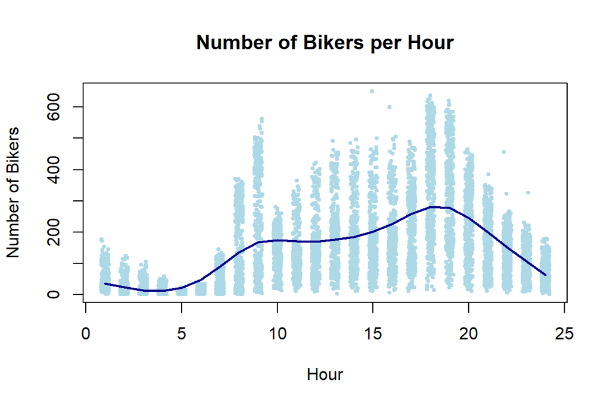

Now if we use boxplots we can see how as the number of bikers increase, so does the standard deviation:

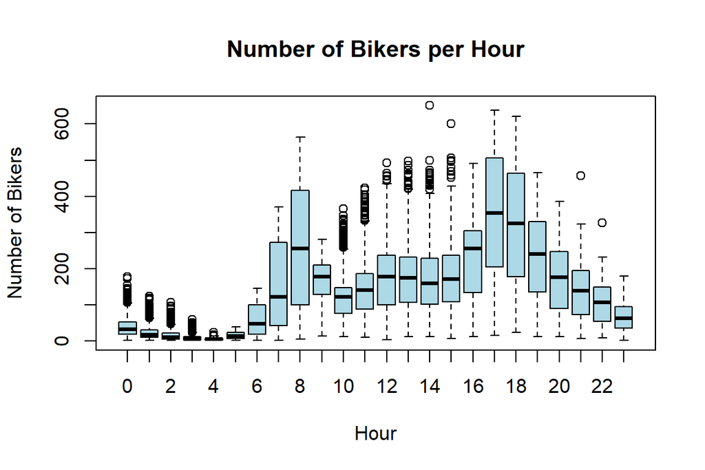

If we use linear model to make predictions and we plot the results as we did before in a scatter plot:

To perform this analysis, first we fit a linear regression model. We are going to show two different ways of doing it:

```r
lm.fit <- lm(
bikers ~ mnth + hr + workingday + temp + weathersit ,
data = Bikeshare)
summary(lm.fit)
```

```
Call:
lm(formula = bikers ~ mnth + hr + workingday + temp + weathersit,
    data = Bikeshare)

Residuals:
    Min      1Q  Median      3Q     Max
-299.00  -45.70   -6.23   41.08  425.29

Coefficients:
                          Estimate Std. Error t value             Pr(>|t|)
(Intercept)                -68.632      5.307 -12.932 < 0.0000000000000002 ***
mnthFeb                      6.845      4.287   1.597             0.110398
mnthMarch                   16.551      4.301   3.848             0.000120 ***
mnthApril                   41.425      4.972   8.331 < 0.0000000000000002 ***
mnthMay                     72.557      5.641  12.862 < 0.0000000000000002 ***
mnthJune                    67.819      6.544  10.364 < 0.0000000000000002 ***
mnthJuly                    45.324      7.081   6.401  0.00000000016282293 ***
mnthAug                     53.243      6.640   8.019  0.00000000000000121 ***
mnthSept                    66.678      5.925  11.254 < 0.0000000000000002 ***
mnthOct                     75.834      4.950  15.319 < 0.0000000000000002 ***
mnthNov                     60.310      4.610  13.083 < 0.0000000000000002 ***
mnthDec                     46.458      4.271  10.878 < 0.0000000000000002 ***
hr1                        -14.579      5.699  -2.558             0.010536 *
hr2                        -21.579      5.733  -3.764             0.000168 ***
hr3                        -31.141      5.778  -5.389  0.00000007260801066 ***
hr4                        -36.908      5.802  -6.361  0.00000000021092958 ***
hr5                        -24.135      5.737  -4.207  0.00002611246755722 ***
hr6                         20.600      5.704   3.612             0.000306 ***
hr7                        120.093      5.693  21.095 < 0.0000000000000002 ***
hr8                        223.662      5.690  39.310 < 0.0000000000000002 ***
hr9                        120.582      5.693  21.182 < 0.0000000000000002 ***
hr10                        83.801      5.705  14.689 < 0.0000000000000002 ***
hr11                       105.423      5.722  18.424 < 0.0000000000000002 ***
hr12                       137.284      5.740  23.916 < 0.0000000000000002 ***
hr13                       136.036      5.760  23.617 < 0.0000000000000002 ***
hr14                       126.636      5.776  21.923 < 0.0000000000000002 ***
hr15                       132.087      5.780  22.852 < 0.0000000000000002 ***
hr16                       178.521      5.772  30.927 < 0.0000000000000002 ***
hr17                       296.267      5.749  51.537 < 0.0000000000000002 ***
hr18                       269.441      5.736  46.976 < 0.0000000000000002 ***
hr19                       186.256      5.714  32.596 < 0.0000000000000002 ***
hr20                       125.549      5.704  22.012 < 0.0000000000000002 ***
hr21                        87.554      5.693  15.378 < 0.0000000000000002 ***
hr22                        59.123      5.689  10.392 < 0.0000000000000002 ***
hr23                        26.838      5.688   4.719  0.00000241267941358 ***
workingday                   1.270      1.784   0.711             0.476810
temp                       157.209     10.261  15.321 < 0.0000000000000002 ***
weathersitcloudy/misty     -12.890      1.964  -6.562  0.00000000005600358 ***
weathersitlight rain/snow  -66.494      2.965 -22.425 < 0.0000000000000002 ***
weathersitheavy rain/snow -109.745     76.667  -1.431             0.152341
---
Signif. codes:  0 '***' 0.001 '**' 0.01 '*' 0.05 '.' 0.1 ' ' 1

Residual standard error: 76.5 on 8605 degrees of freedom
Multiple R-squared:  0.6745,    Adjusted R-squared:  0.6731
F-statistic: 457.3 on 39 and 8605 DF,  p-value: < 0.00000000000000022
```

In this model the first level of hr (0) and mnth (Jan) are treated as the baseline values, and so no coefficient estimates are provided for them: implicitly, their coefficient estimates are zero, and all other levels are measured relative to these baselines.

We created another second model with numbered values for `mnth` and `hr`.

```r
contrasts (Bikeshare$hr) = contr.sum (24)
contrasts (Bikeshare$mnth) = contr.sum (12)
lm.fit <- lm(
  bikers ~  mnth + hr + workingday + temp + weathersit ,
data = Bikeshare)
summary(lm.fit)
```

```
Call:
lm(formula = bikers ~ mnth + hr + workingday + temp + weathersit,
    data = Bikeshare)

Residuals:
    Min      1Q  Median      3Q     Max
-299.00  -45.70   -6.23   41.08  425.29

Coefficients:
                           Estimate Std. Error t value             Pr(>|t|)
(Intercept)                 73.5974     5.1322  14.340 < 0.0000000000000002 ***
mnth1                      -46.0871     4.0855 -11.281 < 0.0000000000000002 ***
mnth2                      -39.2419     3.5391 -11.088 < 0.0000000000000002 ***
mnth3                      -29.5357     3.1552  -9.361 < 0.0000000000000002 ***
mnth4                       -4.6622     2.7406  -1.701              0.08895 .
mnth5                       26.4700     2.8508   9.285 < 0.0000000000000002 ***
mnth6                       21.7317     3.4651   6.272   0.0000000003747098 ***
mnth7                       -0.7626     3.9084  -0.195              0.84530
mnth8                        7.1560     3.5347   2.024              0.04295 *
mnth9                       20.5912     3.0456   6.761   0.0000000000146005 ***
mnth10                      29.7472     2.6995  11.019 < 0.0000000000000002 ***
mnth11                      14.2229     2.8604   4.972   0.0000006740476467 ***
hr1                        -96.1420     3.9554 -24.307 < 0.0000000000000002 ***
hr2                       -110.7213     3.9662 -27.916 < 0.0000000000000002 ***
hr3                       -117.7212     4.0165 -29.310 < 0.0000000000000002 ***
hr4                       -127.2828     4.0808 -31.191 < 0.0000000000000002 ***
hr5                       -133.0495     4.1168 -32.319 < 0.0000000000000002 ***
hr6                       -120.2775     4.0370 -29.794 < 0.0000000000000002 ***
hr7                        -75.5424     3.9916 -18.925 < 0.0000000000000002 ***
hr8                         23.9511     3.9686   6.035   0.0000000016537185 ***
hr9                        127.5199     3.9500  32.284 < 0.0000000000000002 ***
hr10                        24.4399     3.9360   6.209   0.0000000005566528 ***
hr11                       -12.3407     3.9361  -3.135              0.00172 **
hr12                         9.2814     3.9447   2.353              0.01865 *
hr13                        41.1417     3.9571  10.397 < 0.0000000000000002 ***
hr14                        39.8939     3.9750  10.036 < 0.0000000000000002 ***
hr15                        30.4940     3.9910   7.641   0.0000000000000239 ***
hr16                        35.9445     3.9949   8.998 < 0.0000000000000002 ***
hr17                        82.3786     3.9883  20.655 < 0.0000000000000002 ***
hr18                       200.1249     3.9638  50.488 < 0.0000000000000002 ***
hr19                       173.2989     3.9561  43.806 < 0.0000000000000002 ***
hr20                        90.1138     3.9400  22.872 < 0.0000000000000002 ***
hr21                        29.4071     3.9362   7.471   0.0000000000000874 ***
hr22                        -8.5883     3.9332  -2.184              0.02902 *
hr23                       -37.0194     3.9344  -9.409 < 0.0000000000000002 ***
workingday                   1.2696     1.7845   0.711              0.47681
temp                       157.2094    10.2612  15.321 < 0.0000000000000002 ***
weathersitcloudy/misty     -12.8903     1.9643  -6.562   0.0000000000560036 ***
weathersitlight rain/snow  -66.4944     2.9652 -22.425 < 0.0000000000000002 ***
weathersitheavy rain/snow -109.7446    76.6674  -1.431              0.15234
---
Signif. codes:  0 '***' 0.001 '**' 0.01 '*' 0.05 '.' 0.1 ' ' 1

Residual standard error: 76.5 on 8605 degrees of freedom
Multiple R-squared:  0.6745,    Adjusted R-squared:  0.6731
F-statistic: 457.3 on 39 and 8605 DF,  p-value: < 0.00000000000000022
```

Notice that we used contrast for month and hour. `Bikeshare$hr` and `Bikeshare$mnth` are categorical variables representing hour and month, respectively. Sum-to-Zero contrasts ensure that the coefficients of the categories sum to zero. This makes the interpretation of the regression coefficients easier.

For instance, if you have 24 hours in a day and set up sum-to-zero contrasts (`contr.sum(24)`), the sum of all hour coefficients will be zero.

This helps in comparing each category to the overall mean effect, rather than to a reference category.

By default, categorical variables are typically converted to dummy variables (0/1), which can lead to difficulties in interpreting the results, especially with a large number of categories.

In this second model the coefficient estimate for the last level of `mnth` is not zero: instead, it equals the negative of the sum of the coefficient estimates for all of the other levels. Similarly, the coefficient estimate for the last level of hr is the negative of the sum of the coefficient estimates for all of the other levels. This indicates that the difference between the mean level and the coefficients of `hr` and `mnth` in the second model will always total to zero.

We use the linear model to predict the values:

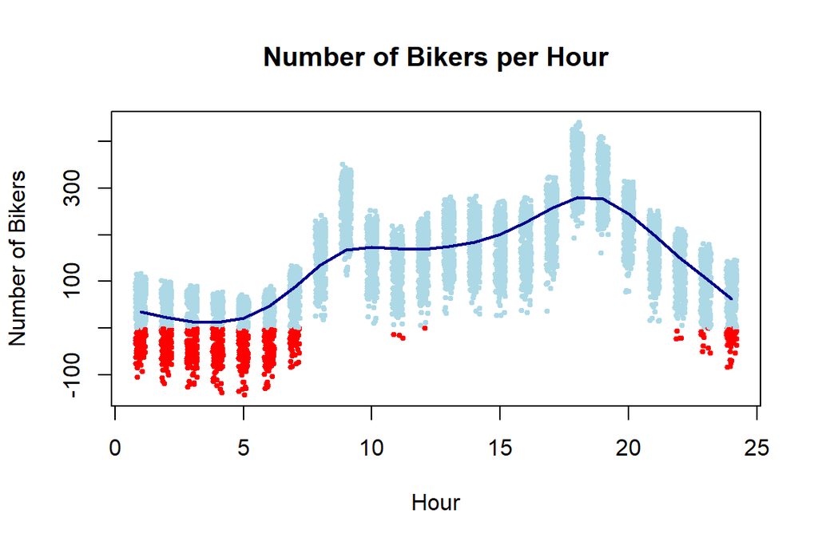

One of first things that we notice is that there are negative values (red points) predicted, and this is because the linear model does not have any type of constraint for that, so **linear models are not the best choice for counts**, we have a better alternative and this is the *Poisson Regression Model*.

The Probability mass function (PMF) is this for a single variance:
$$P(Y = k) = \frac{e^{-\lambda} \lambda^k}{k!}
\tag{13}$$
where:

- $P(Y = k)$: Probability of observing ( k ) events.
- $\lambda$: Average rate (mean number of events) in a given interval.
- $e$: Euler’s number (approximately 2.71828).
- $k!$: Factorial of $k$ (number of events).

Note that for the Poisson distribution, the mean and the variance are directly related, meaning that when the mean is higher, the variance is also higher. In fact we assume that the variance equals the mean.

This formula calculates the probability of exactly $k$ events occurring in a fixed interval when events happen at a constant mean rate and independently of the time since the last event. The Poisson distribution is useful for modeling the number of events in a specific time.

When we have multiple parameters, the model changes to include the covariates:

$$\lambda(X_1,\dots,X_p)=e^{\beta_0+\beta_1X_1+\dots+\beta_pX_p}
\tag{14}$$